# Hockey Match Report

Analyst’s Diary Match Report

# Denmark vs Italy

**24 May 2026**  
IIHF World Championship 2026 – Group Stage

Report generated from the match shot-location pipeline. Metrics marked as proxies are based on OCR-extracted shot coordinates and should be interpreted as transparent spatial indicators rather than official tracking data.

Prepared by Antonin Kremenak

[figure not shown]

# Executive summary

Shots On Goal

DEN: 28 | ITA: 37

Blocked Shots

DEN: 10 | ITA: 13

Scoring Chances

DEN: 15 | ITA: 10

# 1. Public layer: simple match metrics

These visuals are designed as a simple entry point for wider audiences: official shots on goal, blocked shots, shot quality proxies and basic chance creation.

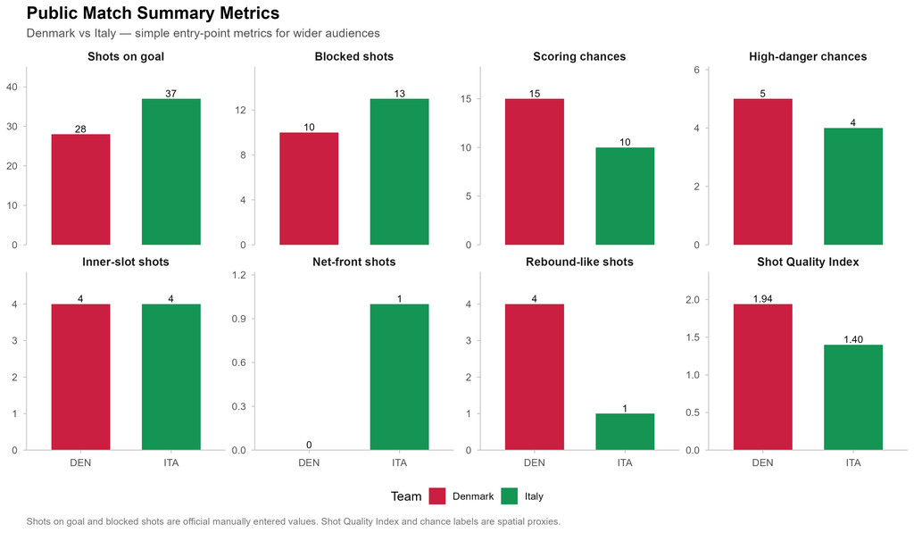

Key Metrics: Denmark vs Italy

24 May 2026 — Shot Quality Index is a location-based proxy, not a trained xG model.

| Metric | DEN | ITA |
| --- | --- | --- |
| OCR detected attempts | 32.00 | 23.0 |
| Corsi attempts | 32.00 | 23.0 |
| Fenwick attempts | 23.00 | 20.0 |
| Scoring chances | 15.00 | 10.0 |
| High-danger chances | 5.00 | 4.0 |
| Shot Quality Index | 1.94 | 1.4 |

# 2. Shot maps and spatial overview

Shot maps show where attempts came from, how dangerous they were spatially, and how shot locations changed across periods.

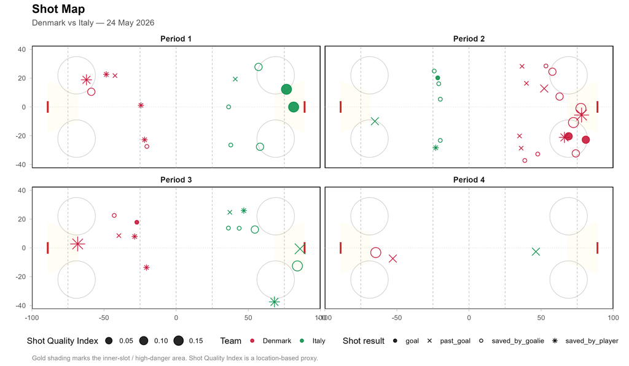

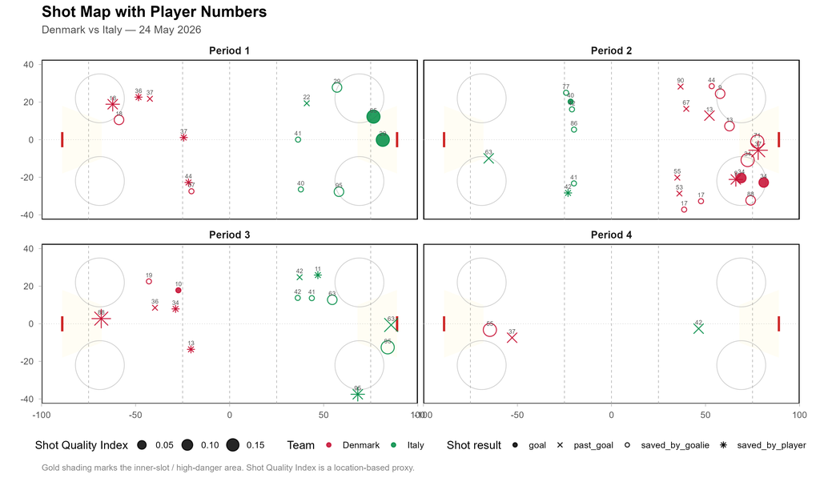

# 3. Shot quality and territorial battle

This section moves from simple shot counts to spatial pressure: location quality, offensive-zone density and period-by-period territorial advantage.

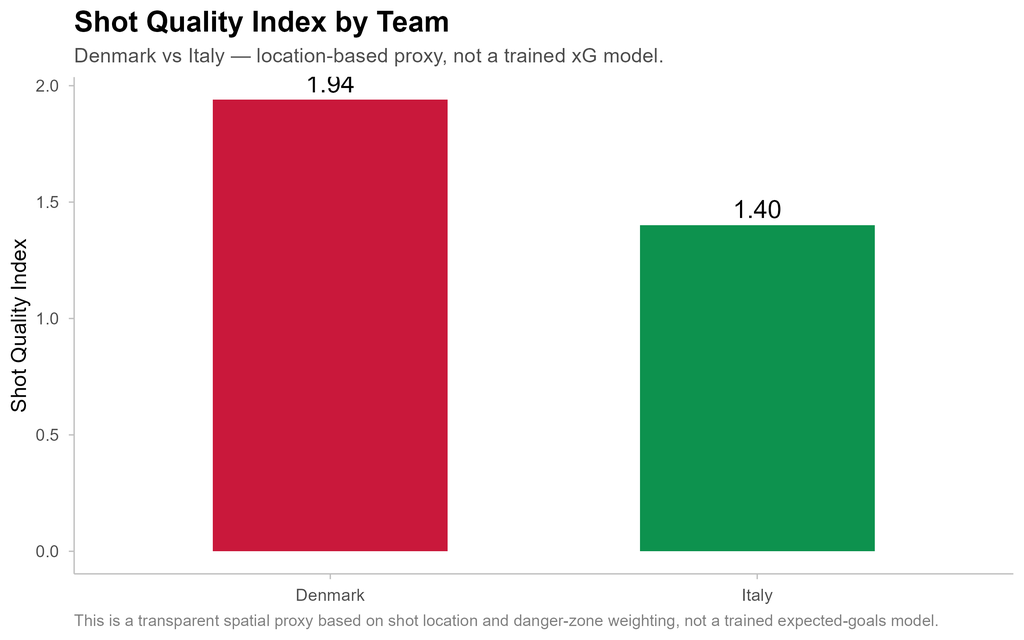

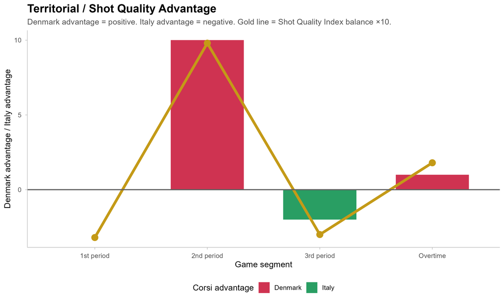

# 4. Offensive-zone density

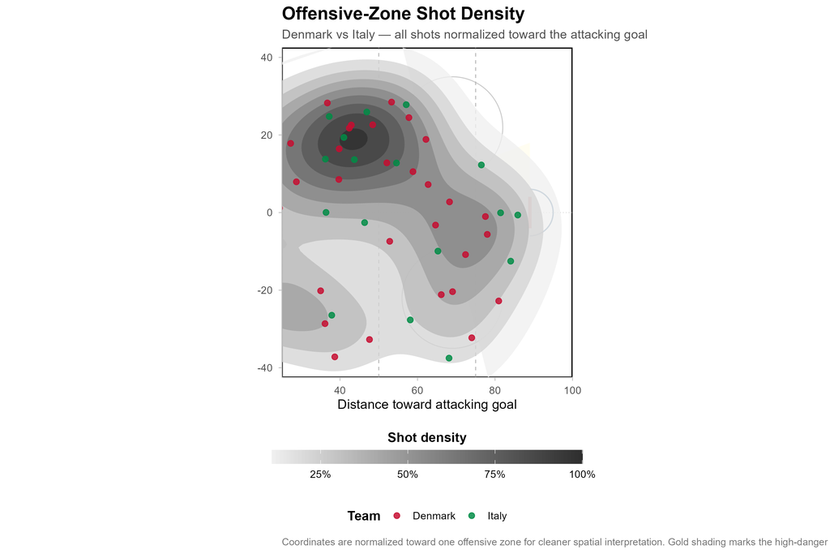

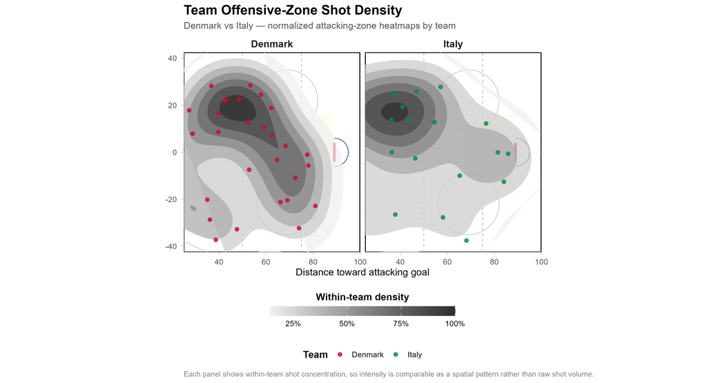

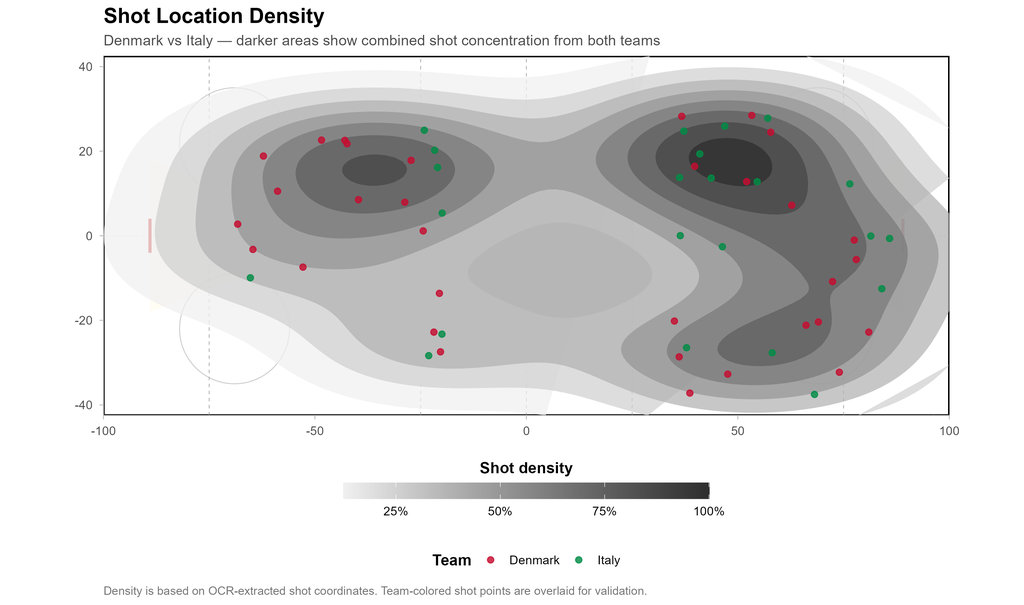

# 5. Advanced insider layer

The following metrics are proxy-based insider indicators built from the available shot-location sample. They are useful for storytelling, but they are not a substitute for full play-by-play or tracking data.

- Denmark showed the highest aggression profile while tied, based on chance rate, slot access and net-front pressure.
- Italy had the strongest danger-oriented shot style: perimeter / point-shot oriented.
- Denmark generated the clearest central-access pattern: strong central-lane access.
- Denmark produced the strongest pressure window between shot sequence 23 and 28.
- Italy had the highest goals-per-SQI finishing efficiency and finished well above spatial chance quality.

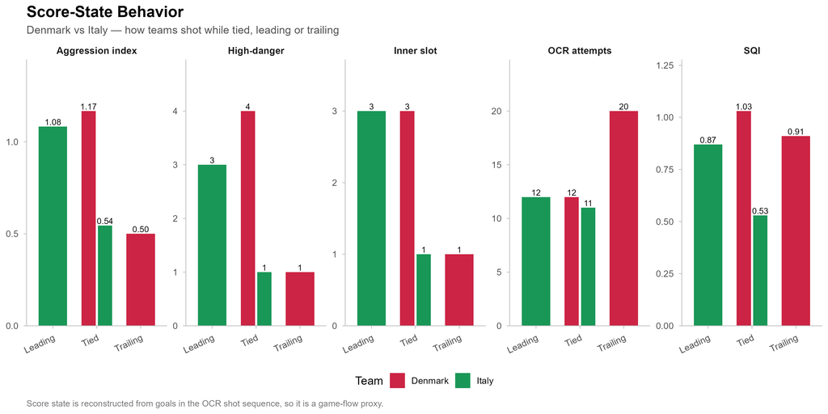

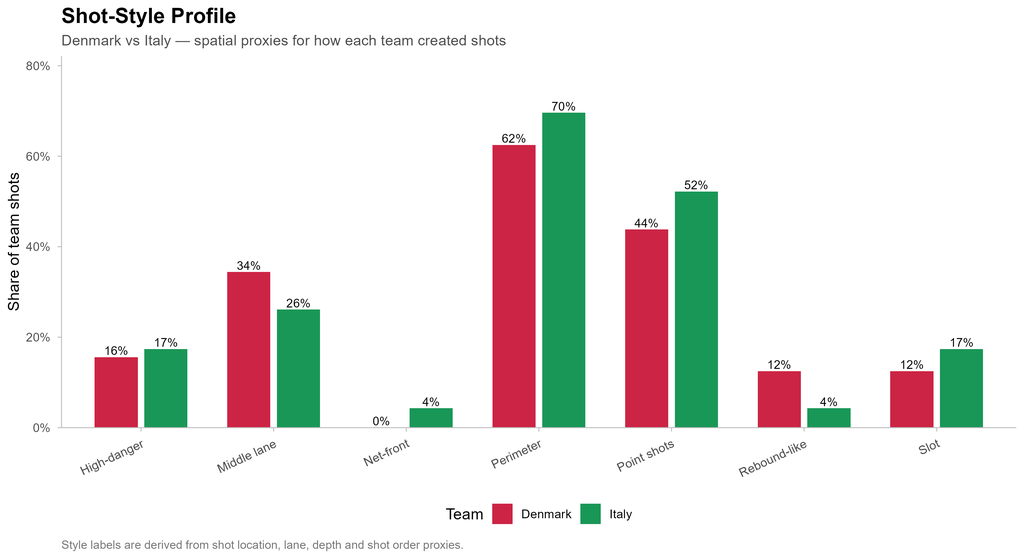

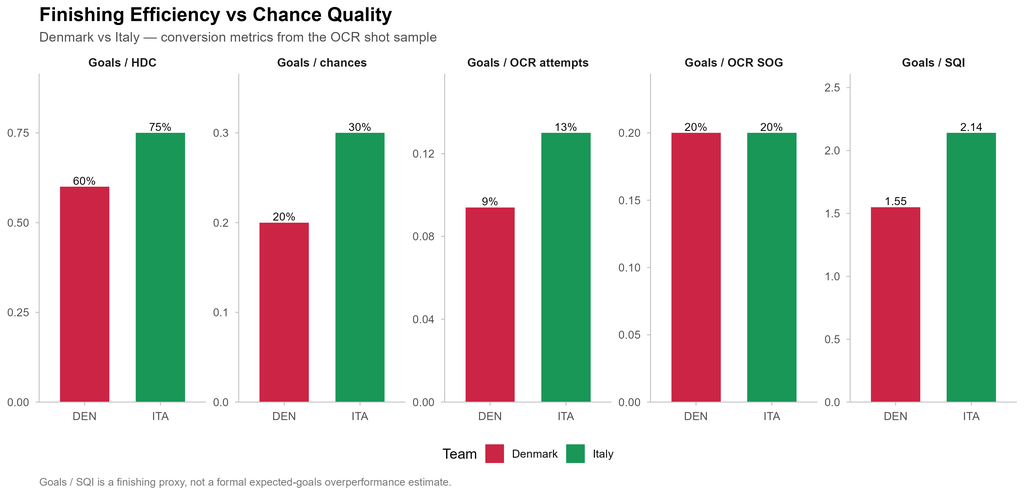

# 6. Momentum

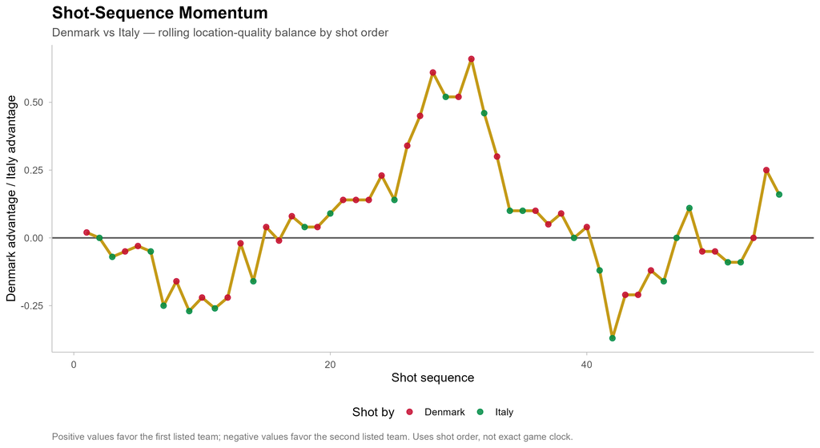

# 7. Player layer

**Player public leaders**

Top players from the OCR-extracted shot sample

| Team | Player no. | OCR attempts | OCR shots on goal | Scoring chances | High-danger chances | Inner-slot shots | Net-front shots | Rebound-like shots | Shot Quality Index | Avg shot distance |
| --- | --- | --- | --- | --- | --- | --- | --- | --- | --- | --- |
| Denmark | 34 | 4 | 3 | 3 | 1 | 1 | 0 | 1 | 0.34 | 33.3 |
| Italy | 63 | 3 | 1 | 3 | 1 | 1 | 1 | 1 | 0.32 | 21.9 |
| Italy | 95 | 3 | 2 | 3 | 1 | 1 | 0 | 0 | 0.32 | 32.6 |
| Denmark | 37 | 5 | 1 | 2 | 1 | 1 | 0 | 1 | 0.31 | 47.9 |
| Denmark | 88 | 2 | 1 | 2 | 1 | 1 | 0 | 0 | 0.25 | 28.3 |
| Italy | 29 | 2 | 2 | 2 | 1 | 1 | 0 | 0 | 0.25 | 24.9 |
| Denmark | 55 | 2 | 1 | 1 | 1 | 0 | 0 | 1 | 0.20 | 41.1 |
| Denmark | 71 | 1 | 1 | 1 | 1 | 1 | 0 | 1 | 0.18 | 11.5 |
| Italy | 65 | 1 | 1 | 1 | 1 | 1 | 0 | 0 | 0.18 | 17.5 |
| Denmark | 13 | 3 | 1 | 2 | 0 | 0 | 0 | 0 | 0.16 | 45.4 |
| Italy | 42 | 5 | 2 | 1 | 0 | 0 | 0 | 0 | 0.15 | 59.3 |
| Denmark | 18 | 2 | 1 | 2 | 0 | 0 | 0 | 0 | 0.14 | 32.4 |

*Player-level statistics are generated from OCR-detected shot markers and spatial coordinates from IIHF shot charts. Due to OCR limitations and embedded IIHF PDF fonts, some player-level counts may contain minor inaccuracies.*

[output not shown]